# ST Neural-ART NPU - Runtime loadable model support

## Example of NPU compiler configuration files

### Memory-pool descriptor files

The `"%STEDGEAI_CORE_DIR%/scripts/N6_reloc/test"` contains a set of configuration and memory-pool descriptor files which can be used. Here are two main points to consider:

- If nonsecure context is used to execute the deployed model, the base @ of the different memory-pools should be set with a nonsecure address (ex. `0x24350000` instead of `0x34350000` for the AXIRAM6 memory).
- For the memory-pools representing an off-chip device, the `"USEMODE_RELATIVE"` attribute should be used.

For test purpose with [STM32N6570-DK](https://www.st.com/en/evaluation-tools/stm32n6570-dk.html) board, different ready-to-use configurations are provided.

| memory-pool desc. file | description |
| --- | --- |
| *stm32n6_reloc.mpool* | **Full memories**. All NPU rams (AXIRAM3..6), AXIRAM2 and external RAM/flash are defined. NPU cache can be used for the external memories. |
| *stm32n6_npuram.mpool* | **NPU memories only**. Only the NPU rams (AXIRAM3..6) are defined. |
| *stm32n6_int.mpool* | **Internal memories only**. Only the NPU RAMs (AXIRAM3..6 and AXIRAM2) are defined. |
| *stm32n6_int2.mpool* | **Internal memories only**. Similar to *stm32n6_int.mpool* but the AXIRAM2 is privileged for the weights. |
| *stm32n6_reloc_ext.mpool* | **External memories only**. Only the external RAM/flash are defined. NPU cache can be used for the external memories. |

For information and test purpose, the *non” reloc memory-pool descriptor files are provided which can be used with a *normal* deployment flow.

Part of the *`./test/mpool/stm32n6_reloc.mpool`* file:

```json
    ...
    {
        "fname": "AXISRAM6",
        "name":  "npuRAM6",
        "fformat": "FORMAT_RAW",
        "prop":   { "rights": "ACC_WRITE", "throughput": "HIGH", "latency": "LOW",
                    "byteWidth": 8, "freqRatio": 1.25, "read_power": 18.531, "write_power": 16.201 },
        "offset": { "value": "0x34350000", "magnitude":  "BYTES" },
        "size":   { "value": "448",        "magnitude": "KBYTES" }
    },
    {
        "fname": "xSPI1",
        "name":  "hyperRAM",
        "fformat": "FORMAT_RAW",
        "prop":   { "rights": "ACC_WRITE", "throughput": "MID", "latency": "HIGH",
                    "byteWidth": 2, "freqRatio": 5.00, "cacheable": "CACHEABLE_ON",
                    "read_power": 380, "write_power": 340.0, "constants_preferred": "true" },
        "offset": { "value": "0x90000000", "magnitude":  "BYTES" },
        "size":   { "value": "32",         "magnitude": "MBYTES" },
        "mode":   "USEMODE_RELATIVE"
    },
    {
        "fname": "xSPI2",
        "name":  "octoFlash",
        "fformat": "FORMAT_RAW",
        "prop":   { "rights": "ACC_READ",  "throughput": "MID", "latency": "HIGH",
                    "byteWidth": 1, "freqRatio": 6.00, "cacheable": "CACHEABLE_ON",
                    "read_power": 110, "write_power": 400.0, "constants_preferred": "true" },
        "offset": { "value": "0x70400000", "magnitude":  "BYTES" },
        "size":   { "value": "64",         "magnitude": "MBYTES" },
        "mode":   "USEMODE_RELATIVE"
    }
    ...
```

### “neural_art.json” file

The `"%STEDGEAI_CORE_DIR%/scripts/N6_reloc/test"` contains two examples of configuration file using the requested memory-pool descriptor files. They provide different profiles using different memory configurations which are aligned with the generic AI test validation.

[output not shown]

Part of the *`./test/neural_art_reloc.json`* file:

```json
  ...
   "test" : {
    "memory_pool": "./mpools/stm32n6_reloc.mpool",
      "options": "--native-float --cache-maintenance --Ocache-opt --enable-virtual-mem-pools --Os
                    --optimization 3 --Oauto-sched --all-buffers-info --csv-file network.csv"
   },
   "test-ec" : {
    "memory_pool": "./mpools/stm32n6_reloc.mpool",
        "options": "--native-float --cache-maintenance --Ocache-opt --enable-virtual-mem-pools --Os
                    --optimization 3 --Oauto-sched --all-buffers-info --csv-file network.csv --enable-epoch-controller"
   },
  ...
```

# Performance impacts

## Accuracy

No difference with the nonrelocatable or static implementation.

## Set up and inference time

For the inference time (after the install/init steps), *no significant* difference is expected versus a nonrelocatable or static implementation. Only the set-up time is impacted to install/create an instance of a given model. The installation time is directly proportional to the number of relocations, and the size of the code/data sections according to the used COPY/XIP mode. Note that if the memory initializers need to be copied into the internal RAMs, this extra time is equivalent to the static implementation.

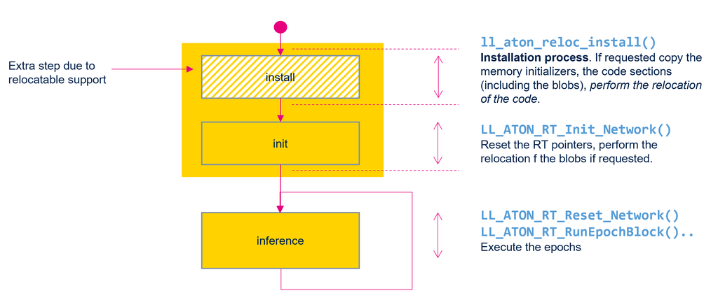

Install/init time overhead

- [STM32N6570-DK](https://www.st.com/en/evaluation-tools/stm32n6570-dk.html) board (DEV mode), overdrive clock setting (NPU 1 GHz, MCU 800 MHz).
- By default, the external flash is used to store the weights/params.
- Internal RAMs (AXIRAM3,..6) are used to store the activations.
- The executable RAM region is located in the internal AXIRAM1 (this is equivalent to the static case where the application is also executed from the AXIRAM1).

| yolov5 224 (nano) | static mode (absolute @ only) | reloc mode (copy) | reloc mode (xip) (*) |
| --- | --- | --- | --- |
| inference time (w/ ec) | 10.4 ms, 95.45 inf/s | 10.5 ms, 94.9 inf/s | 10.6 ms, 94.6 inf/s |
| inference time (w/o ec) | 13.2 ms, 75.35 inf/s | 13.0 ms, 77.1 inf/s | 14.3 ms, 69.6 inf/s |
| install/init time (ms) (w/ ec) | 0.0 / 0.03 | 11.7 / 0.73 | 10.9 / 0.93 |
| install/init time (ms) (w/o ec) | 0.0 / 0.03 | 11.2 / 0.03 | 10.8 / 0.03 |

**(*)** with the epoch controller, as the blob should be updated, it is fetched from the executable RAM region (AXIRAM1). We only observe an impact in the case where the configuration code is fetched from the external FLASH, w/o epoch controller support.

For the reloc mode with epoch controller support, the `'install/init'` time is mainly due to the copy of the blobs in the AXIRAM1 and the requested relocations to resolve the weights/params addresses in the different blobs.

**Case where only the AXIRAMx is used for the activations and the weights/params (~2 Mbytes)**

| yolov5 224 (nano) | static mode (absolute @ only) | reloc mode (copy) | reloc mode (xip) |
| --- | --- | --- | --- |
| inference time (w/ ec) | 9.5 ms, 105.3 inf/s | 9.5 ms, 105.8 inf/s | 9.6 ms, 104.6 inf/s |
| install/init time (ms) (w/ ec) | 17+ / 0.03 | 18.1 / 0.03 | 18.1 / 0.03 |

The `'install/init'` time is similar in both case. It is mainly represented by the copy of the memory initializers from the FLASH location to the internal RAMs. No extra relocation for the weights/activations is requested (all weighs/activations addresses are absolutes).

## Memory layout overhead

In comparison with a static implementation, the relocation mode involves two additional sections, GOT/REL, which are used to support the position-independent code/data. The size is directly proportional to the number of relocating references.

# LL ATON runtime API extension

To enable the support of a runtime loadable model, the LL_ATON files should be compiled with the following C-define:

```
LL_ATON_RT_RELOC
```

The `LL_ATON_RT_RELOC` C-define activates the code paths and functionalities required to manage and install runtime loadable models. Ensuring that this macro is defined during compilation is crucial for the successful deployment and execution of runtime loadable models.

## ll_aton_reloc_install()

```c
int ll_aton_reloc_install(const uintptr_t file_ptr, const ll_aton_reloc_config *config,
                          NN_Instance_TypeDef *nn_instance);
```

#### Description

The `ll_aton_reloc_install()` function acts as a runtime dynamic loader. It is used to install and to create an instance of a memory-mapped runtime loadable module. By providing the model image pointer (`file_ptr`), configuration details, and neural network instance, users can set up the model for execution. The function performs compatibility checks, initializes memory pools, and installs/relocates code and data sections as needed.

#### Parameters

- **`file_ptr`**: A `uintptr_t` value representing the pointer to the image of the runtime loadable model. This parameter specifies the location of the model image to be installed.
- **`config`**: A pointer to an ll_aton_reloc_config structure. This parameter provides the configuration details for how the model should be installed, including memory addresses and sizes.
- **`nn_instance`**: A pointer to an `NN_Instance_TypeDef` structure. This parameter is updated to handle the installed model, creating an instance of the neural network.

#### Return Value

- The function returns an integer value. A return value of `0` typically indicates success, while a nonzero value indicates that an error occurred during the installation process.

#### Steps Executed

1. **Checking step**
   - This step checks the compatibility of the binary object against the runtime environment (static part of the firmware). The main points checked include:
     - The version and content of the binary file header.
     - MCU type and whether the FPU (floating-point unit) is enabled (context/setting of the caller is used).
     - Secure or nonsecure context.
     - Whether the binary module has been compiled with the `LL_ATON_EB_DBG_INFO` or `LL_ATON_RT_ASYNC` C-defines.
     - Version of the used LL_ATON files.
2. **Memory-Pool initialization step**
   - If requested, this step initializes the used memory regions for the given model. Specifically:
     - If read/write memory pools handle the params/weights section, the associated memory region is initialized with values from the params/weights section.
     - Optionally, if the `AI_RELOC_RT_LOAD_MODE_CLEAR` flag is set, the read/write memory region handling the activations is cleared.
3. **Code/Data installation and relocation step**
   - According to the `AI_RELOC_RT_LOAD_MODE_COPY` or `AI_RELOC_RT_LOAD_MODE_XIP` flag:
     - The code/data sections are copied into the executable RAM region.
     - The relocation process is performed to update references.
     - Register the call-backs

### *ll_aton_reloc_config* C-struct

The purpose of the `ll_aton_reloc_config` C structure is to provide the parameters which are requested to install a runtime loadable model.

```c
typedef struct _ll_aton_reloc_config {
    uintptr_t exec_ram_addr;  /* base@ of the exec memory region to place the relocatable code/data (8-Bytes aligned) */
    uint32_t exec_ram_size;   /* max size in byte of the exec memory region */
    uintptr_t ext_ram_addr;   /* base@ of the external memory region to place the external pool (if requested) */
    size_t ext_ram_size;      /* max size in byte of the external memory region */
    uintptr_t ext_param_addr; /* base@ of the param memory region (if requested) */
    uint32_t mode;
  } ll_aton_reloc_config;
```

| mode | description |
| --- | --- |
| `AI_RELOC_RT_LOAD_MODE_XIP` | XIP (Execute In Place) execution mode |
| `AI_RELOC_RT_LOAD_MODE_COPY` | COPY execution mode |
| `AI_RELOC_RT_LOAD_MODE_CLEAR` | Reset the used activation memory regions |

## ll_aton_reloc_set_callbacks()

```c
int ll_aton_reloc_set_callbacks(const NN_Instance_TypeDef *nn_instance, const struct ll_aton_reloc_callback *cbs)
```

#### Description

The `ll_aton_reloc_set_callbacks` function is used to overwrite the default registration of the callbacks done in the `ll_aton_reloc_install` function. *This function is optional*.

| Callback services | description |
| --- | --- |
| assert/lib error | to implement the management of the errors generated by the embedded LL ATON functions |
| NPU/MCU cache maintenance operations | to implement the NPU/MCU cache maintenance operations |
| LL_ATON_LIB_xxx | to implement the LL ATON LIB services to support the hybrid epochs |

#### Parameters

- **`nn_instance`**: A pointer to the neural network instance (`NN_Instance_TypeDef`).
- **`cbs`**: A pointer to a `ll_aton_reloc_callback` structure (see `ll_aton_reloc_network.h` file).

#### Return Value

- The function returns an integer value. A return value of `0` typically indicates success, while a nonzero value indicates that an error occurred during the installation process.

## ll_aton_reloc_get_info()

```c
int ll_aton_reloc_get_info(const uintptr_t file_ptr, ll_aton_reloc_info *rt);
```

#### Description

The `ll_aton_reloc_get_info` function is used to obtain the main dimensioning information from the image of a runtime loadable model. This information can include details such as the size, memory requirements, and other relevant attributes of the model. By providing a pointer to the model image and a reference to an `ll_aton_reloc_info` structure, users can retrieve and store the necessary information to properly configure and manage the runtime loadable model.

This function is particularly useful for setting up the memory regions and ensuring that the model can be correctly loaded and executed within the available resources.

#### Parameters

- **`file_ptr`**: A `uintptr_t` value representing the pointer to the image of the runtime loadable model. This parameter specifies the location of the model image from which the information will be retrieved.
- **`rt`**: A pointer to an ll_aton_reloc_info structure. This parameter is used to store the retrieved dimensioning information of the runtime loadable model. The function fills this structure with the relevant details.

#### Return Value

- The function returns an integer value. A return value of `0` typically indicates success, while a nonzero value indicates that an error occurred during the operation.

### *ll_aton_reloc_info* C-struct

```cpp
  typedef struct _ll_aton_reloc_info
  {
    const char *c_name;          /* c-name of the model */
    uint32_t variant;            /* 32-b word to handle the reloc rt version,
                                    the used ARM Embedded compiler,
                                    Cortex-Mx (CPUID) and if the FPU is requested */
    uint32_t code_sz;            /* size of the code (header + txt + rodata + data + got + rel sections) */
    uint32_t params_sz;          /* size (in bytes) of the weights */
    uint32_t acts_sz;            /* minimum requested RAM size (in bytes) for the activations buffer */
    uint32_t ext_ram_sz;         /* requested external ram size for the activations (and params) */
    uint32_t rt_ram_xip;         /* minimum requested RAM size to install it, XIP mode */
    uint32_t rt_ram_copy;        /* minimum requested RAM size to install it, COPY mode */
    const char *rt_version_desc; /* rt description */
    uint32_t rt_version;         /* rt version */
    uint32_t rt_version_extra;   /* rt version extra */
  } ll_aton_reloc_info;
```

| member | description |
| --- | --- |
| `c_name` | indicates the name of the model. |
| `variant` | or-red 32-bit value indicating the used Arm compiler, CPUID of the Cortex®-M,.. (see `ll_aton_reloc_network.h` file) |
| `code_sz` | size in bytes of all code/data sections representing the model: header+txt+rodata+data+got+rel sections |
| `params_sz` | total size (in bytes) of the params/weights section |
| `acts_sz` | total size (in bytes) of the activations |
| `ext_ram_sz` | requested size (in bytes) of the external RAM memory |
| `rt_ram_xip` | requested size (in bytes) of read/write execution memory region (XIP mode) |
| `rt_ram_copy` | requested size (in bytes) of read/write execution memory region (COPY mode) |
| `rt_version_desc` | (debug info) string describing the used LL runtime version |
| `rt_version` | LL runtime version: `major << 24 \| minor << 16 \| sub << 8` |
| `rt_version` | (debug info) extra dev version value |

## ll_aton_reloc_get_mem_pool_desc()

```c
ll_aton_reloc_mem_pool_desc *ll_aton_reloc_get_mem_pool_desc(const uintptr_t file_ptr, int index);
```

#### Description

The `ll_aton_reloc_get_mem_pool_desc` function allows to obtain information about the part of the memory-pools which are used for a given model. By providing a pointer to the model image and an index, users can retrieve the necessary information through the returned `ll_aton_reloc_mem_pool_desc` structure.

The `ll_aton_reloc_get_mem_pool_desc` function allows users to obtain information about parts of the memory pools used for a given model. By providing a pointer to the model image and an index, users can retrieve the necessary information through the returned `ll_aton_reloc_mem_pool_desc` structure.

#### Parameters

- **`file_ptr`**: A `uintptr_t` value representing the pointer to the image of the runtime loadable model. This parameter specifies the location of the model image from which the information will be retrieved.
- **`index`**: Index of the requested descriptor.

#### Return Value

- The function returns a reference of a `ll_aton_reloc_mem_pool_desc` object. If the specified index is out of range, the function may return NULL.

#### Example

A typical snippet of code to display memory pool C-descriptors.

```c
  ll_aton_reloc_mem_pool_desc *mem_c_desc;
  int index = 0;

  while ((mem_c_desc = ll_aton_reloc_get_mem_pool_desc((uintptr_t)bin, index)))
  {
    printf(" %d: flags=%x foff=%d dst=%x s=%d\n", index, mem_c_desc->flags,
           mem_c_desc->foff, mem_c_desc->dst, mem_c_desc->size);
    index++;
  }
```

### *ll_aton_reloc_mem_pool_desc* C-struct

```c
typedef struct _ll_aton_reloc_mem_pool_desc
{
  const char *name; /* name */
  uint32_t flags;   /* type definition: 32b:4x8b <type><data_type><reserved><id> */
  uint32_t foff;    /* offset in the binary file */
  uint32_t dst;     /* dst @ */
  uint32_t size;    /* real size */
} ll_aton_reloc_mem_pool_desc;
```

`AI_RELOC_MPOOL_GET_XXX(flags)` macros (see `ll_aton_reloc_network.h` file) can be used to know the attributes of the memory pool.

## ll_aton_reloc_get_input/output_buffers_info()

```c
const LL_Buffer_InfoTypeDef *ll_aton_reloc_get_input_buffers_info(const NN_Instance_TypeDef *nn_instance,
                                                                  int32_t num);
const LL_Buffer_InfoTypeDef *ll_aton_reloc_get_output_buffers_info(const NN_Instance_TypeDef *nn_instance,
                                                                   int32_t num);
```

#### Description

The `ll_aton_reloc_get_input/output_buffers_info` function is used to obtain information about a specific input/output buffer of a neural network instance. This can be useful for understanding the structure and requirements of the input data for the neural network. By providing the neural network instance and the index of the desired input buffer, users can retrieve detailed information about the buffer, such as its size, type, and memory location.

#### Parameters

- **`nn_instance`**: A pointer to the neural network instance (`NN_Instance_TypeDef`). This parameter specifies the neural network instance for which the input/output buffer information is to be retrieved.
- **`num`**: An integer specifying the index of the input/output buffer whose description is to be retrieved. The index is zero-based, meaning that `num = 0` refers to the first input buffer, `num = 1` refers to the second input buffer, and so on.

#### Return Value

- The function returns a pointer to a `LL_Buffer_InfoTypeDef` structure, which contains the description of the specified input/output buffer. If the specified buffer index is out of range, the function may return NULL.

## ll_aton_reloc_set_input/output()

```c
LL_ATON_User_IO_Result_t ll_aton_reloc_set_input(const NN_Instance_TypeDef *nn_instance, uint32_t num, void *buffer,
                                                 uint32_t size);
LL_ATON_User_IO_Result_t ll_aton_reloc_set_output(const NN_Instance_TypeDef *nn_instance, uint32_t num, void *buffer,
                                                  uint32_t size);
```

#### Description

Both `ll_aton_reloc_set_input` and `ll_aton_reloc_set_output` functions are used to configure the address of the input and output buffers for a neural network instance, respectively. By providing the neural network instance, buffer index, buffer pointer, and buffer size, users can set up the necessary memory regions for input and output data.

Warning

These functions should be only used when the deployed model is generated with the ‘–no-inputs-allocation’ or/and ‘–no-outputs-allocation’ respectively.

#### Parameters

- **`nn_instance`**: A pointer to the neural network instance (`NN_Instance_TypeDef`). This parameter specifies the neural network instance for which the output buffer is to be set.
- **`num`**: An unsigned integer specifying the index of the output buffer to be set. The index is zero-based.
- **`buffer`**: A pointer to the buffer that will hold the output data. This parameter specifies the memory location where the output data is stored.
- **`size`**: An unsigned integer specifying the size of the input/output buffer in bytes.

#### Return Value

- The function returns a value of type `LL_ATON_User_IO_Result_t`. This return value indicates the result of the operation, such as success or an error code.